# Lesson 4

### Scatterplots and Perceived Audience Size

Notes:

- diagonal line == accuracy line
- people tend to guess ‘round’ numbers: 50, 100, 200
- people underestimate their audience

### Scatterplots

Notes:

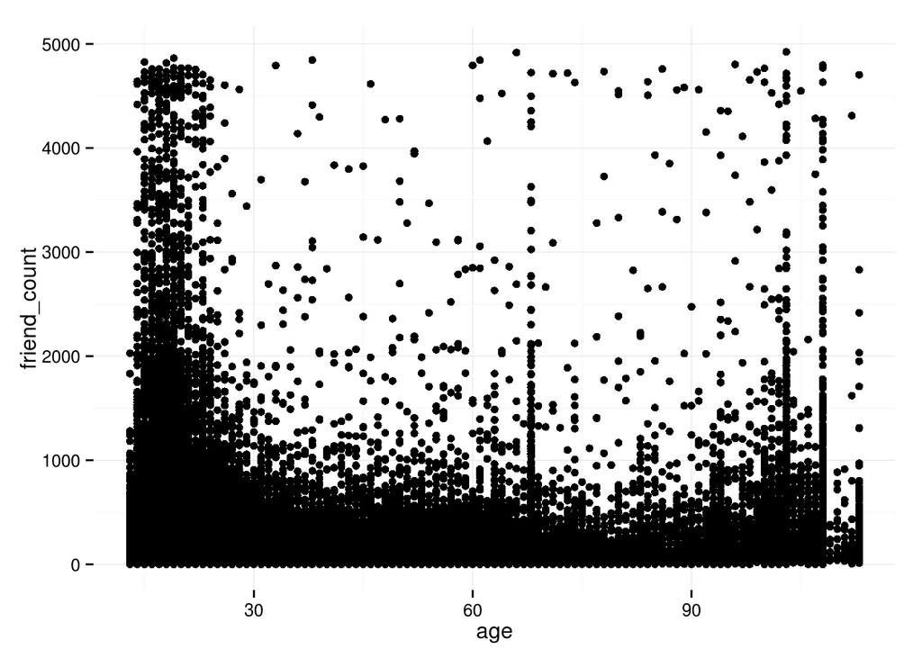

```r
library(ggplot2)
library(ggthemes)
theme_set(theme_minimal())
pf <- read.csv('pseudo_facebook.tsv', sep = '\t')

ggplot(aes(x = age, y = friend_count), data = pf) +
  geom_point()
```

#### What are some things that you notice right away?

Response:

- younger people seems to have more friends (and definitely more high-friend outliers)
- age 70 (69?) looks strongly overrepresented
- ages > 100 looks strongly overrepresented

### ggplot Syntax

Notes:

- ggplot2 tutorial: http://www.ceb-institute.org/bbs/wp-content/uploads/2011/09/handout_ggplot2.pdf
- list of geoms: http://docs.ggplot2.org/current/
- Grammar of Graphics (book behind ggplot2 grammar): http://www.amazon.com/The-Grammar-Graphics-Statistics-Computing/dp/0387245448

### Overplotting

Notes:

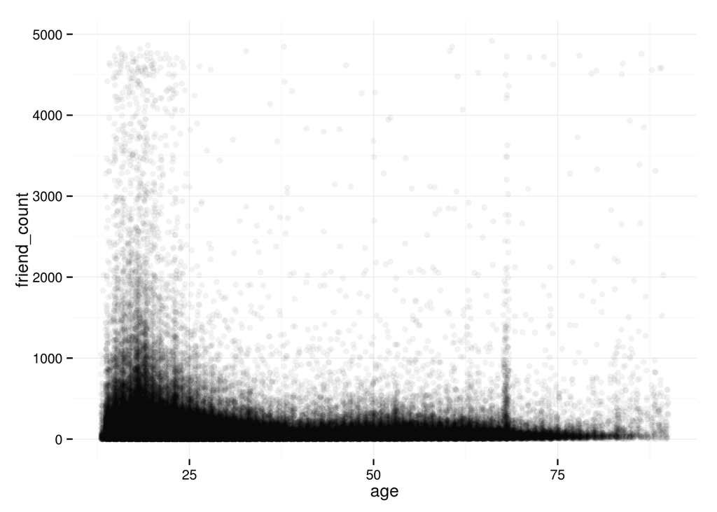

```r
# to find out min and max of pf$age
# summary(pf$age)
# 13.00   20.00   28.00   37.28   50.00  113.00

# also, setting alpha = 1/20 - it takes 20 points to build to 'full' colour point.
# geom_jitter (instead of geom_point) - at random noise to disperse the vertical columns
ggplot(aes(x = age, y = friend_count), data = pf) +
  geom_jitter(alpha = 1/20) +
  #scale_y_log10() +
  xlim(13, 90)
```

#### What do you notice in the plot?

Response:

- younger users friedn count isn’t much higher than older ones - it’s just many high value outliers which creates such impression
- younger users have more friends than olders ones
- younger users have more high value outliers
- there is more younger users (?)
- distribution is looking a bit bimodal with values decreasing ~40 and going up ~50 ***

### Coord_trans()

Notes: Look up the documentation for coord_trans() and add a layer to the plot that transforms friend_count using the square root function. Create your plot!

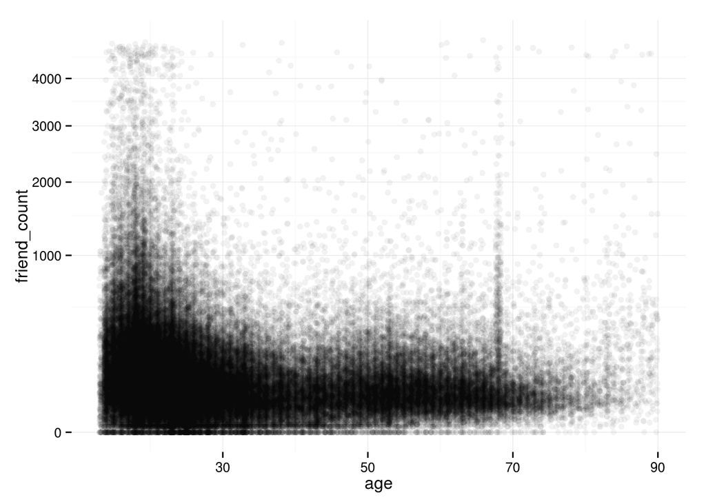

```r
# Dealing with jitter values < 0
#ggplot(aes(x = age, y = friend_count), data = pf[pf$friend_count>0,]) +
#  geom_jitter(alpha = 1/20) +
#  coord_trans(ytrans = "sqrt") +
#  xlim(13, 90)

ggplot(aes(x = age, y = friend_count), data = pf) +
  geom_jitter(alpha = 1/20, position = position_jitter(h = 0)) +
  coord_trans(ytrans = "sqrt") +
  xlim(13, 90)
```

#### What do you notice?

There is more younger users of facebook (density of points for age < 30 is higher than for other ages)

### Alpha and Jitter

Examine the relationship between friendships_initiated (y) and age (x) using the ggplot syntax.

We recommend creating a basic scatter plot first to see what the distribution looks like and then adjusting it by adding one layer at a time.

Notes:

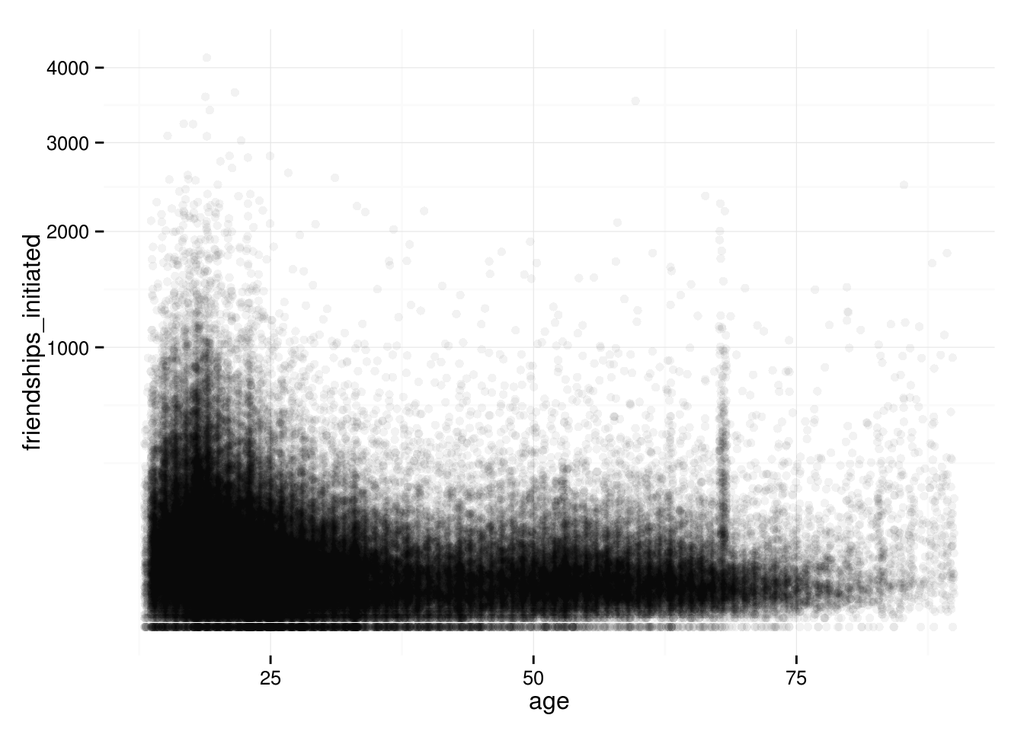

```r
ggplot(aes(x = age, y = friendships_initiated), data = pf) +
  geom_jitter(alpha = 1/20, position = position_jitter(h = 0)) +
  scale_y_sqrt() +
  xlim(13, 90)
```

### Overplotting and Domain Knowledge

Notes:

- choose proper (sometimes transformed) values for x and y. e.g. Moira changed the x and y scales from ‘how many friends saw your post’ to ‘% of friends saw your post’. This scales nicely with # of friends people have.

### Conditional Means

More dplyr resources:

- Introduction to dplyr: http://rstudio-pubs-static.s3.amazonaws.com/11068_8bc42d6df61341b2bed45e9a9a3bf9f4.html
- Hadley Wickham “dplyr” talk:
  - http://www.r-bloggers.com/hadley-wickham-presents-dplyr-at-user-2014/
  - http://www.r-bloggers.com/hadley-wickhams-dplyr-tutorial-at-user-2014-part-1/
  - http://www.r-bloggers.com/hadley-wickhams-dplyr-tutorial-at-user-2014-part-2/
- lapply blog post: https://rollingyours.wordpress.com/2014/10/20/the-lapply-command-101/

```r
library(dplyr)
age_groups <- group_by(pf, age)
pf.fc_by_age = summarise(age_groups,
                         friend_count_mean = mean(friend_count),
                         friend_count_median = median(friend_count),
                         n = n())
pf.fc_by_age <- arrange(pf.fc_by_age, age)
```

```r
pf %>%
  group_by(age) %>%
  summarise(friend_count_mean = mean(friend_count),
            friend_count_median = median(friend_count),
            n = n()) %>%
  arrange(age)
```

```
## Source: local data frame [101 x 4]
##
##      age friend_count_mean friend_count_median     n
##    (int)             (dbl)               (dbl) (int)
## 1     13          164.7500                74.0   484
## 2     14          251.3901               132.0  1925
## 3     15          347.6921               161.0  2618
## 4     16          351.9371               171.5  3086
## 5     17          350.3006               156.0  3283
## 6     18          331.1663               162.0  5196
## 7     19          333.6921               157.0  4391
## 8     20          283.4991               135.0  3769
## 9     21          235.9412               121.0  3671
## 10    22          211.3948               106.0  3032
## ..   ...               ...                 ...   ...
```

Create your plot!

```r
head(pf.fc_by_age, 20)
```

```
## Source: local data frame [20 x 4]
##
##      age friend_count_mean friend_count_median     n
##    (int)             (dbl)               (dbl) (int)
## 1     13          164.7500                74.0   484
## 2     14          251.3901               132.0  1925
## 3     15          347.6921               161.0  2618
## 4     16          351.9371               171.5  3086
## 5     17          350.3006               156.0  3283
## 6     18          331.1663               162.0  5196
## 7     19          333.6921               157.0  4391
## 8     20          283.4991               135.0  3769
## 9     21          235.9412               121.0  3671
## 10    22          211.3948               106.0  3032
## 11    23          202.8426                93.0  4404
## 12    24          185.7121                92.0  2827
## 13    25          131.0211                62.0  3641
## 14    26          144.0082                75.0  2815
## 15    27          134.1473                72.0  2240
## 16    28          125.8354                66.0  2364
## 17    29          120.8182                66.0  1936
## 18    30          115.2080                67.5  1716
## 19    31          118.4599                63.0  1694
## 20    32          114.2800                63.0  1443
```

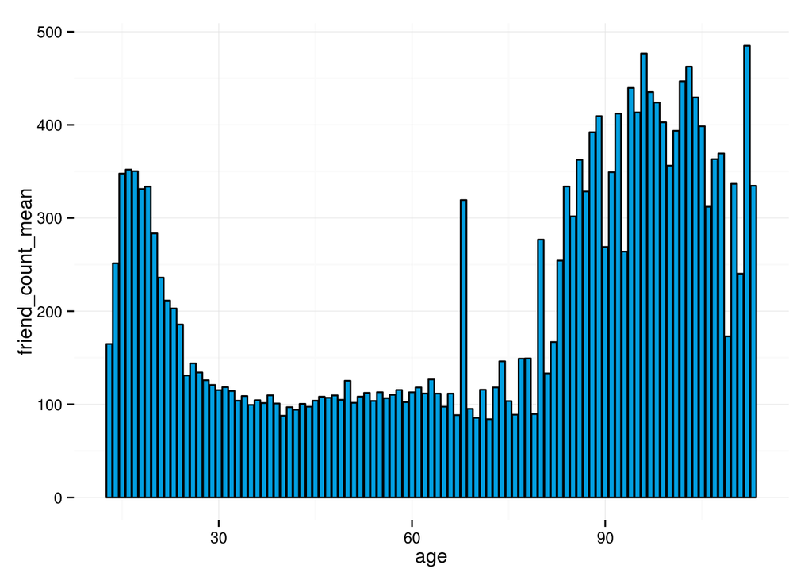

```r
ggplot(aes(x=age, y=friend_count_mean), data=pf.fc_by_age) +
  geom_bar(stat = 'identity', color='black', fill='#02a0e2')
```

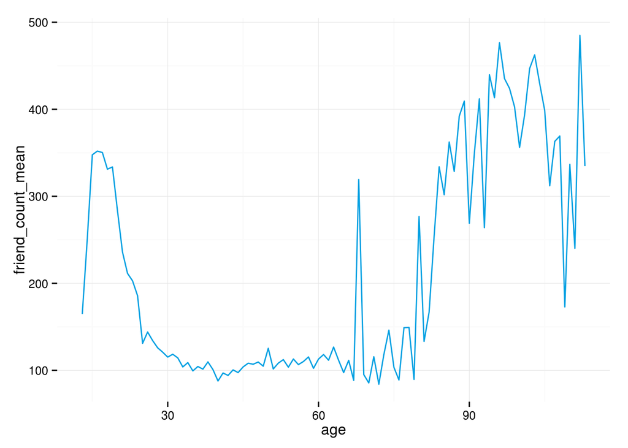

```r
ggplot(aes(x=age, y=friend_count_mean), data=pf.fc_by_age) +
  #geom_point() +
  geom_line(stat = 'identity', color='#02a0e2')
```

### Overlaying Summaries with Raw Data

We take the jittered friendship graph as the base and add 4 summary overlays on top of it:

- mean (black line)
- median (blue line)
- 10th and 90th percentile (blue dashed lines)

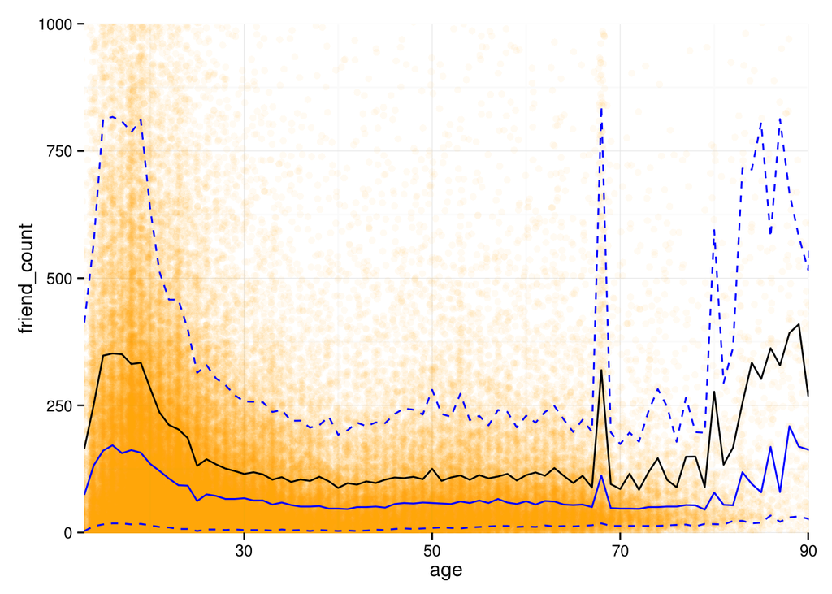

```r
ggplot(aes(x = age, y = friend_count), data = pf) +
  #xlim(13, 90) +
  #coord_trans(ytrans = "sqrt") +
  coord_cartesian(xlim = c(13, 90), ylim=c(0, 1000)) +
  geom_point(alpha = 0.05,
             position = position_jitter(h = 0),
             color = 'orange') +
  geom_line(stat = 'summary', fun.y = mean) +
  geom_line(stat = 'summary', fun.y = median, color = 'blue') +
  geom_line(stat = 'summary', fun.y = quantile, probs = .1, linetype = 2, color = 'blue') +
  geom_line(stat = 'summary', fun.y = quantile, probs = .9, linetype = 2, color = 'blue')
```

#### What are some of your observations of the plot?

Response:

### Moira: Histogram Summary and Scatterplot

See the Instructor Notes of this video to download Moira’s paper on perceived audience size and to see the final plot.

Notes:

- histograms are used to show quntitative data about how user perceive their audience

### Correlation

Notes:

- visual guide to correlation: https://s3.amazonaws.com/udacity-hosted-downloads/ud651/correlation_images.jpeg
- correlation coefficient: http://www.r-tutor.com/elementary-statistics/numerical-measures/correlation-coefficient
- udacity correlation: https://www.udacity.com/course/viewer#!/c-ud201/l-1345848540/m-171582737
- different methods of correlation: http://www.statisticssolutions.com/correlation-pearson-kendall-spearman/

```r
cor.test(pf$age, pf$friend_count, method="pearson")
```

```
##
##  Pearson's product-moment correlation
##
## data:  pf$age and pf$friend_count
## t = -8.6268, df = 99001, p-value < 2.2e-16
## alternative hypothesis: true correlation is not equal to 0
## 95 percent confidence interval:
##  -0.03363072 -0.02118189
## sample estimates:
##         cor
## -0.02740737
```

Look up the documentation for the cor.test function.

What’s the correlation between age and friend count? Round to three decimal places. Response: cor = -0.027

Results: -0.3 < cor < 0.3 - no correlation  
0.3 < cor < 0.5 - small correlation  
0.5 < cor < 0.7 - moderate correlation  
0.7 < cor - large correlation

### Correlation on Subsets

Notes:

```r
with(pf[pf$age<=70,] , cor.test(age, friend_count))
```

```
##
##  Pearson's product-moment correlation
##
## data:  age and friend_count
## t = -52.592, df = 91029, p-value < 2.2e-16
## alternative hypothesis: true correlation is not equal to 0
## 95 percent confidence interval:
##  -0.1780220 -0.1654129
## sample estimates:
##        cor
## -0.1717245
```

### Correlation Methods

Notes: correlation numbers are useful but do not give as much insight as plotting the data.

## Create Scatterplots

Notes:

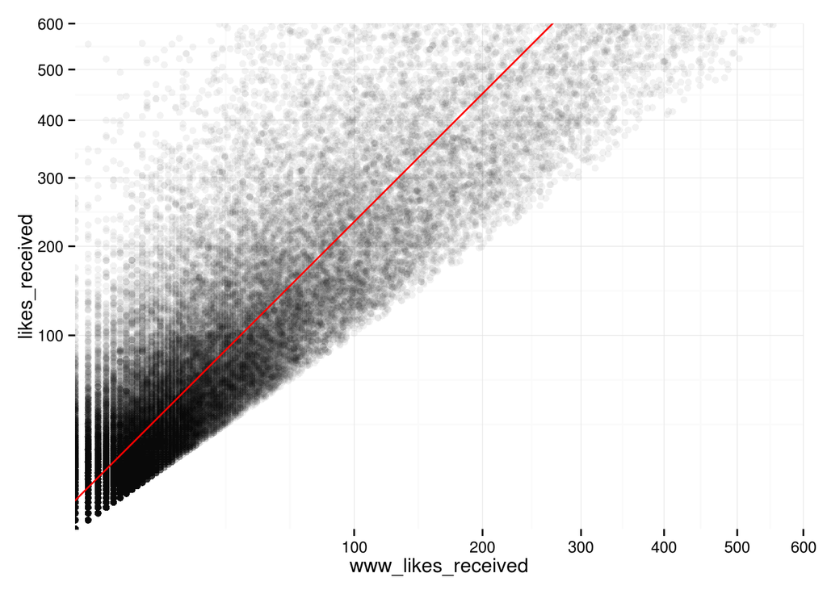

```r
# There are few significant outliers that extend the axis. Let's remove them as 1-2% top outliers. Where to cut?
# quantile(pf$likes_received, probs = c(.90, .95, .98))

ggplot(aes(x = www_likes_received, y = likes_received), data=pf) +
  geom_point(alpha = 0.05) +
  coord_cartesian(xlim = c(1, 600), ylim = c(1, 600)) +
  scale_x_sqrt() +
  scale_y_sqrt() +
  # add correlation line
  geom_smooth(method = 'lm', color = 'red')
```

What’s the correlation betwen the two variables? Include the top 5% of values for the variable in the calculation and round to 3 decimal places.

```r
cor.test(pf$www_likes_received, pf$likes_received, method="pearson")
```

```
##
##  Pearson's product-moment correlation
##
## data:  pf$www_likes_received and pf$likes_received
## t = 937.1, df = 99001, p-value < 2.2e-16
## alternative hypothesis: true correlation is not equal to 0
## 95 percent confidence interval:
##  0.9473553 0.9486176
## sample estimates:
##       cor
## 0.9479902
```

Response: 0.948

### Moira on Correlation

Notes:

- be aware of the correlation of your variables (e.g. # of status updates and # of photos uploaded). Such correlations might describe same behavior/situation (here: how user is engaged). Later on, as you try to build models, you should choose if you want to keep both strongly correlated vars as model input.

### More Caution with Correlation

Notes:

```r
#install.packages('alr3')
library(alr3)
```

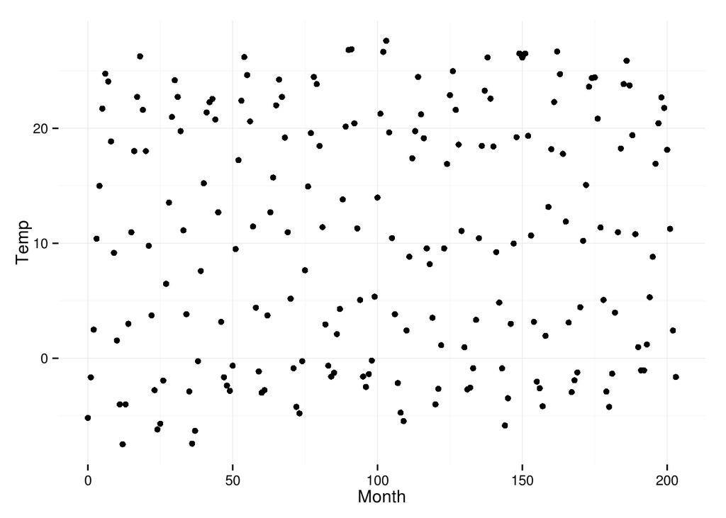

```r
data(Mitchell)

ggplot(aes(x = Month, y = Temp), data = Mitchell) +
  geom_point()
```

### Noisy Scatterplots

1. Take a guess for the correlation coefficient for the scatterplot.

0.05

2. What is the actual correlation of the two variables? (Round to the thousandths place)

```r
cor.test(Mitchell$Month, Mitchell$Temp, method="pearson")
```

```
##
##  Pearson's product-moment correlation
##
## data:  Mitchell$Month and Mitchell$Temp
## t = 0.81816, df = 202, p-value = 0.4142
## alternative hypothesis: true correlation is not equal to 0
## 95 percent confidence interval:
##  -0.08053637  0.19331562
## sample estimates:
##        cor
## 0.05747063
```

0.057

### Making Sense of Data

Break up the x-axis in 12 months increments

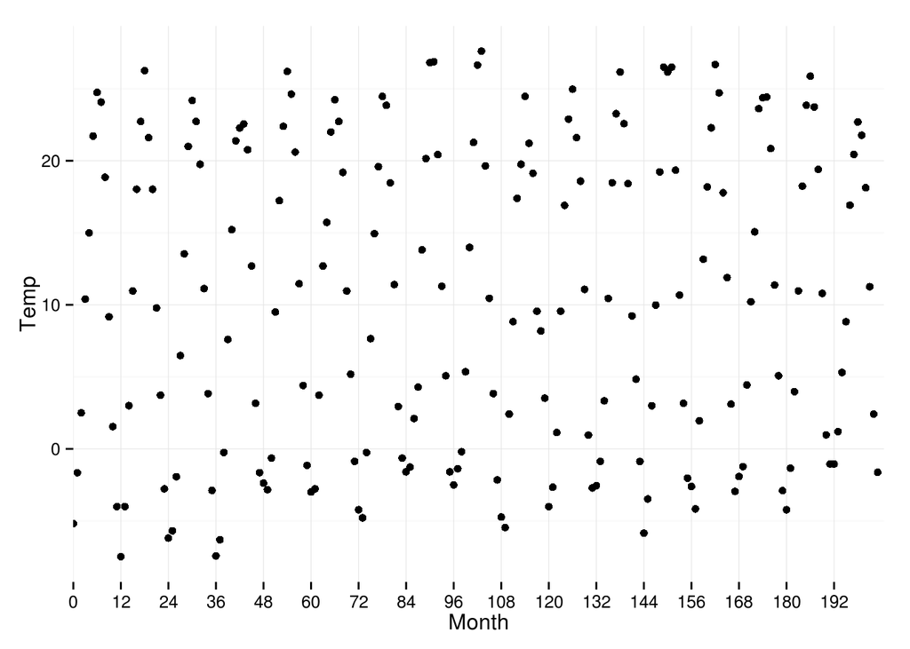

```r
ggplot(aes(x = Month, y = Temp), data = Mitchell) +
  geom_point() +
  scale_x_discrete(breaks = seq(0, 203, 12))
```

### A New Perspective

Zoom in into the plot, stretch y-axis and extend the x-axis.

Watch the solution video and check out the Instructor Notes! Notes:

- make sure you use whole context about the data you have. Here: months are cyclic
- use proper scales for the plot: here, with x extended and y stretched, the cyclicity of data could be seen
- William Playfair and the Psychology of Graphs: http://www.psych.utoronto.ca/users/spence/Spence%20(2006).pdf
- there are other tests that can find the cyclic correlation in data (e.g. library(energey); dcor.ttest())

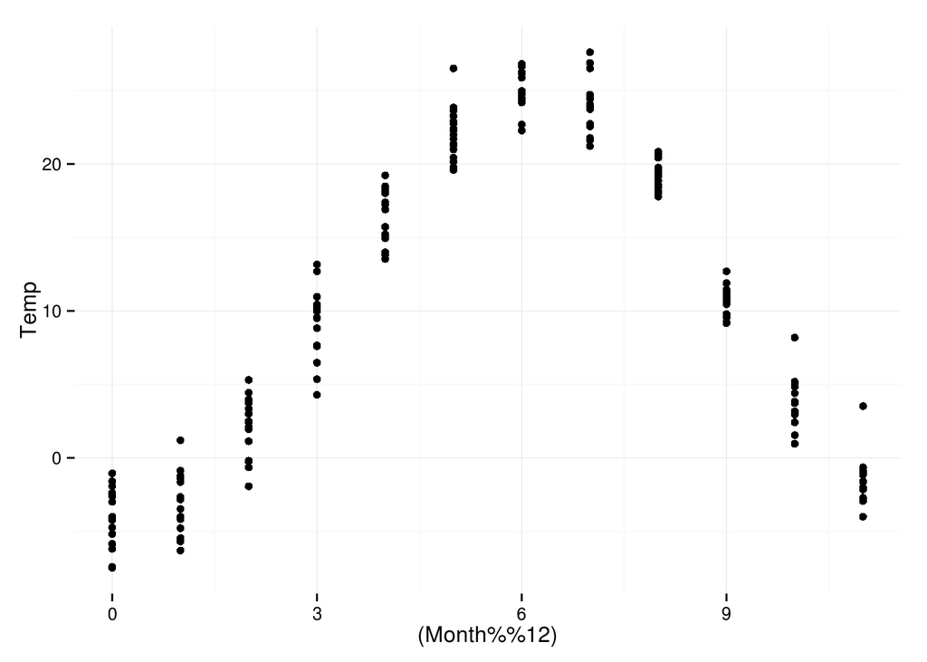

```r
ggplot(aes(x=(Month%%12),y=Temp),data=Mitchell)+
  geom_point()
```

### Understanding Noise: Age to Age Months

Notes: concrete values of means are just sample of the data and still contains some noise inside them. The effect is event more visible if we count mean_friend_count / age_by_month.

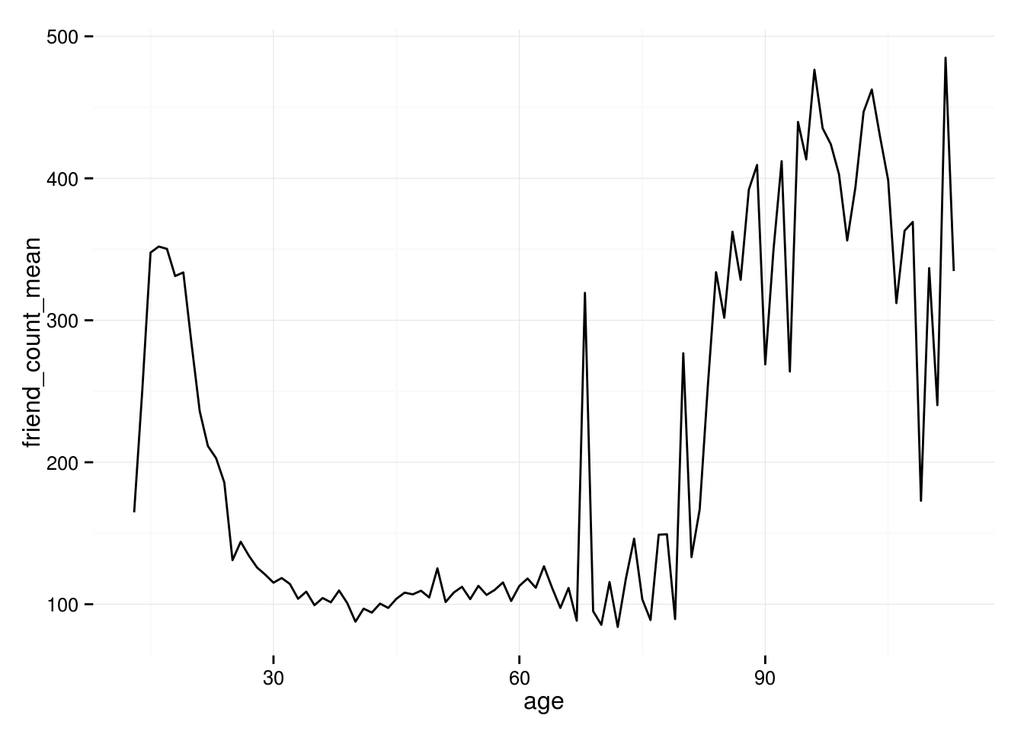

```r
ggplot(aes(x=age, y=friend_count_mean), data=pf.fc_by_age) +
  geom_line()
```

```r
head(pf.fc_by_age, 10)
```

```
## Source: local data frame [10 x 4]
##
##      age friend_count_mean friend_count_median     n
##    (int)             (dbl)               (dbl) (int)
## 1     13          164.7500                74.0   484
## 2     14          251.3901               132.0  1925
## 3     15          347.6921               161.0  2618
## 4     16          351.9371               171.5  3086
## 5     17          350.3006               156.0  3283
## 6     18          331.1663               162.0  5196
## 7     19          333.6921               157.0  4391
## 8     20          283.4991               135.0  3769
## 9     21          235.9412               121.0  3671
## 10    22          211.3948               106.0  3032
```

```r
pf.fc_by_age[17:19,]
```

```
## Source: local data frame [3 x 4]
##
##     age friend_count_mean friend_count_median     n
##   (int)             (dbl)               (dbl) (int)
## 1    29          120.8182                66.0  1936
## 2    30          115.2080                67.5  1716
## 3    31          118.4599                63.0  1694
```

### Age with Months Means

```r
# Use December 31 as the reference date.
pf$age_with_months = pf$age + (12 - pf$dob_month)/12
```

Programming Assignment

```r
pf.fc_by_age_months <- pf %>%
  group_by(age_with_months) %>%
  summarise(friend_count_mean = mean(friend_count),
            friend_count_median = median(friend_count),
             n = n()) %>%
  arrange(age_with_months)
head(pf.fc_by_age_months)
```

```
## Source: local data frame [6 x 4]
##
##   age_with_months friend_count_mean friend_count_median     n
##             (dbl)             (dbl)               (dbl) (int)
## 1        13.16667          46.33333                30.5     6
## 2        13.25000         115.07143                23.5    14
## 3        13.33333         136.20000                44.0    25
## 4        13.41667         164.24242                72.0    33
## 5        13.50000         131.17778                66.0    45
## 6        13.58333         156.81481                64.0    54
```

### Noise in Conditional Means

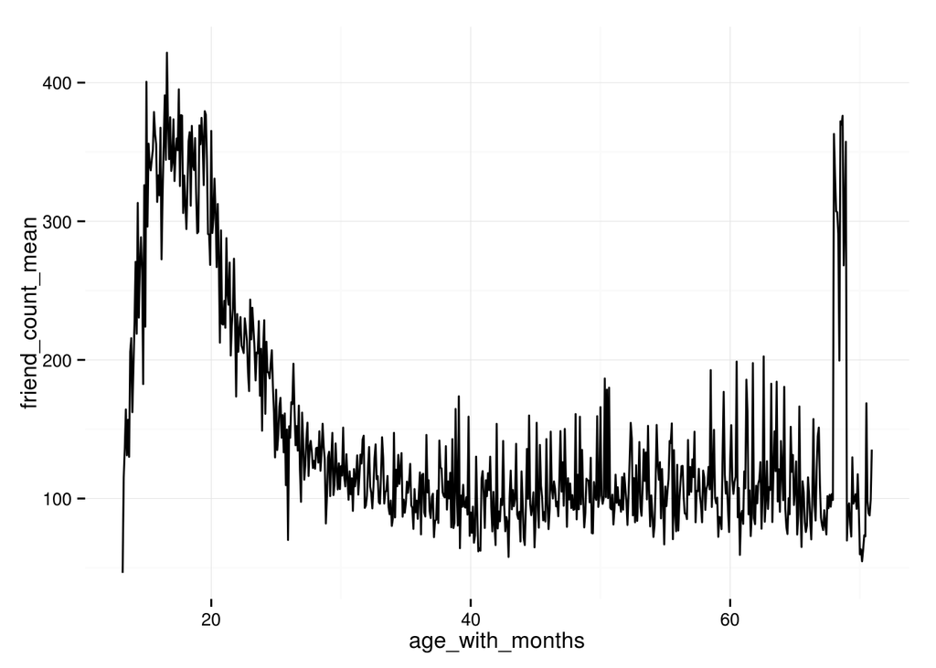

```r
ggplot(aes(x=age_with_months), data=pf.fc_by_age_months[pf.fc_by_age_months$age_with_months<71,]) +
  geom_line(aes(y = friend_count_mean))
```

```r
#  geom_line(aes(y = friend_count_mean), color='#109618') +
#  geom_line(aes(y = friend_count_median), color='#cc3637')
```

### Smoothing Conditional Means

Notes:

- by decreasing the bucket size (age -> age_by_month) we increase the noise of the plot.
- plots below represent variance/bias tradeoff (e.g. miss features (age 69))

Local Regression:

- explained visually: http://simplystatistics.org/2014/02/13/loess-explained-in-a-gif/
- Simply Statistics blog: http://simplystatistics.org/
- local regression wikipedia: https://en.wikipedia.org/wiki/Local_regression

```
## geom_smooth: method="auto" and size of largest group is <1000, so using loess. Use 'method = x' to change the smoothing method.
## geom_smooth: method="auto" and size of largest group is <1000, so using loess. Use 'method = x' to change the smoothing method.
```

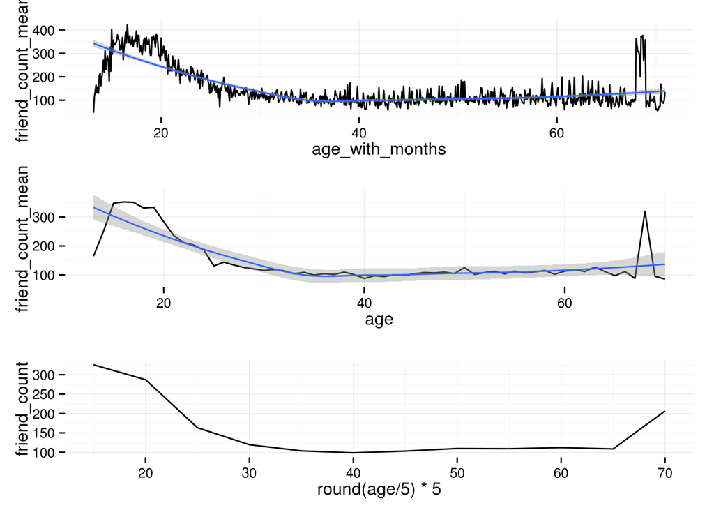

```r
p1 <- ggplot(aes(x = age, y = friend_count_mean), data = subset(pf.fc_by_age, age < 71)) +
  geom_line() +
  geom_smooth()

p2 <- ggplot(aes(x = age_with_months, y = friend_count_mean), data = subset(pf.fc_by_age_months, age_with_months < 71)) +
  geom_line() +
  geom_smooth()
# smoothened mean
p3 <- ggplot(aes(x = round(age / 5) * 5, y = friend_count), data = subset(pf, age<71)) + geom_line(stat = 'summary', fun.y = mean)

library(gridExtra)
grid.arrange(p2, p1, p3, ncol = 1)
```

### Which Plot to Choose?

Notes:

### Analyzing Two Variables

Reflection:

- Lesson covered:
  - scatterplots
  - conditional means
  - correlation
  - noise
- scatterplots:
  - main tool for analysis of two variables
  - great tool to reveal outliers and anomalies in data (age 69, different variance for young and old users)
  - with proper layers (jitter, mean, median, qunatiles), one scatterplot presents clearly lots of information
- conditional means:
  - augments scatterplots
  - perfect for showing trends
  - makes me thing about groups of data (here: age) and how to split it
- correlation
  - quick test of hypothesis (is #of friends going down with age?)
  - you need to understand the data before (correlation of soil temp vs month)
- noise
  - varianve vs bias
  - use smoothening to remove the noise and find trends

Extra notes:

- A deep dive into Bivariate Data Analysis: http://dept.stat.lsa.umich.edu/~kshedden/Courses/Stat401/Notes/401-bivariate-slides.pdf
  - bivariate = two parameters for each simple random sample
  - marginal property = property that describes X values only or Y values only
  - joint property = property that describex X and Y at the same time
  - joint distribution = complete summary of stat props of (X, Y)
    - joint distribution is not described completelty by marginal distribution of both variables
  - scatterplot = most important graphical summary of data
  - correlation
    - Pearson - r == coefficient (Pearson correlation coefficient) - covariance (numerator of r) - page 21 and 22 shows chart how values contribute to coefficient value
  - … more

Click **KnitHTML** to see all of your hard work and to have an html page of this lesson, your answers, and your notes!